- **Author:** [Dace Apšvalka](https://www.mrc-cbu.cam.ac.uk/people/dace.apsvalka/) with edits by [Rik Henson](https://www.mrc-cbu.cam.ac.uk/people/rik.henson/)
- **Date:** November 2024
- **conda environment**: This uses the [mri environment](https://github.com/RikHenson/PythonNeuroimagingCourse/blob/main/mri_environment.yml)

# fMRI Data Quality Control and Pre-processing

In fMRI research, ensuring high-quality data and performing robust pre-processing are crucial steps in obtaining reliable results. Poor quality data or incorrect preprocessing can introduce artifacts, reduce sensitivity, and lead to inaccurate conclusions. Fortunately, the neuroimaging community has developed powerful tools to streamline these tasks, notably through the use of [BIDS-Apps](https://bids-apps.neuroimaging.io/).

In this tutorial, we will focus on two BIDS-Apps for fMRI data: [MRIQC](https://mriqc.readthedocs.io/en/latest/) and [fMRIPrep](https://fmriprep.org/en/stable/).

- **MRIQC** generates quality control metrics and visual reports for both anatomical and functional MRI data, helping you assess the quality of your dataset before proceeding with analysis.
- **fMRIPrep** is a comprehensive pre-processing pipeline. It takes raw fMRI data and prepares it for analysis by performing tasks such as motion correction, slice time correction, distortion correction, and spatial normalisation to standard templates like MNI space.

At the end of the tutorial, we will provide a brief example of how to use [NiPype](https://nipype.readthedocs.io/en/latest/) to build your own pre-processing pipeline.

Here are some recommended short videos to help better understand the principles of fMRI pre-processing:

```python
from IPython.display import display, HTML

display(HTML('''
<div style="width: 1200px; margin: 0; display: flex; justify-content: space-around;">
    <div style="text-align: center;">
        <h3>fMRI Artifacts and Noise (12 min) </h3>
        <iframe width="560" height="315" src="https://www.youtube.com/embed/7Kk_RsGycHs" frameborder="0" allow="picture-in-picture" allowfullscreen></iframe>
    </div>
    <div style="text-align: center;">
        <h3>Pre-processing I (10 min)</h3>
        <iframe width="560" height="315" src="https://www.youtube.com/embed/Qc3rRaJWOc4" frameborder="0" allow="picture-in-picture" allowfullscreen></iframe>
    </div>
</div>

<div style="width: 1200px; margin: 0; display: flex; justify-content: space-around;">
    <div style="text-align: center;">
        <h3>Pre-processing II (8 min) </h3>
        <iframe width="560" height="315" src="https://www.youtube.com/embed/qamRGWSC-6g" frameborder="0" allow="picture-in-picture" allowfullscreen></iframe>
    </div>
</div>
'''))
```

fMRI Artifacts and Noise (12 min)

[video not shown]

Pre-processing I (10 min)

[video not shown]

Pre-processing II (8 min)

[video not shown]

**Table of contents**

1. Quality control with MRIQC  
   1.1. MRIQC Participant level  
   1.2. MRIQC Group level  
   1.3. MRIQC output
2. Typical pre-processing pipeline
3. Preprocessing with fMRIPrep  
   3.1. Preprocessing of structural MRI  
   3.2. BOLD preprocessing  
   3.3. fMRIPrep generated Methods section  
   3.4. Example scipt to run fMRIPrep
4. Pre-processing with NiPype

We first need to set up directories:

```python
import os
wd = '/mnt/c/Users/rh01/PythonNeuroimagingCourse/FaceRecognition/' # <-- CHANGE TO YOURS
os.chdir(wd)
print(f"Working directory currently {os.getcwd()}")
```

```
Working directory currently /mnt/c/Users/rh01/PythonNeuroimagingCourse/FaceRecognition
```

## Quality control with MRIQC

Before we begin any processing with our fMRI data, it’s important to assess the quality of the acquisition.

**MRIQC** extracts a variety of [Image Quality Metrics (IQMs)](https://mriqc.readthedocs.io/en/latest/measures.html) from both structural and functional MRI data.

For detailed information, you can refer to the [MRIQC Documentation](https://mriqc.readthedocs.io/en/latest/).

MRIQC is a [BIDS-App](https://bids-apps.neuroimaging.io/), meaning it is designed to work seamlessly with datasets that follow the BIDS format. Its command-line interface follows the BIDS-Apps standard:

`mriqc bids-root/ output-folder/ participant`

The most effective way to run MRIQC is through containerised versions, such as Docker or Singularity/Apptainer. Containers encapsulate the software and all its dependencies, including a minimal operating system, into a single, self-contained image. This approach ensures that the software runs seamlessly across different computing environments, enhancing shareability, portability and, importantly, reproducibility. For information how to install Apptainer App and the MRIQC `*.sif` file, see Section 2.2 of https://github.com/RikHenson/PythonNeuroimagingCourse/blob/main/fMRI_analysis_on_Windows.ipynb.

### Running MRIQC in Terminal

Below, we call MRIQC via an apptainer. For this, we need to bind the working directory to a variable (using the apptainer "-B" command). In example below, "FP" is bound to the working directory and used for later arguments to `mriqc`. To preprocess a single participant (eg sub-15), you could paste the command below into a linux terminal:

```
apptainer run \
        -B /mnt/c/Users/rh01/PythonNeuroimagingCourse/FaceRecognition:/FP \
        /mnt/c/Users/rh01/PythonNeuroimagingCourse/mriqc_v24.1.0.sif \
        /FP/data \
        /FP/data/derivatives/mriqc \
        --work-dir /FP/scratch/mriqc \
        participant \
        --participant-label "15" \
        --float32 \
        --n_procs 16 --mem_gb 8 --ants-nthreads 16 \
        --modalities T1w bold \
        --no-sub
```

The first line attaches our project directory to the Apptainer app...  
...which is defined by the second line.  
The third line is the BIDS data directory...  
...and the fourth line is the output directory.

The --work-dir is where intermediate results are stored.

### Running MRIQC in Bash script

Alternatively, you could save the above code as a `bash` script file, and pass it with the variable `subject` to run each subject. If you're experienced with bash, you could even pass this script to software like `SLURM` that could run each subject on a different core:

```
# ======================================================================
# Example generic bash script for MRIQC
# ======================================================================
apptainer run \
    -B "$PROJECT_PATH":/MyProject \
    /imaging/local/software/singularity_images/mriqc/mriqc-22.0.1.simg \
    /MyProject/data \
    /MyProject/data/derivatives/mriqc/ \
    --work-dir /MyProject/scratch/mriqc/"$subject" \
    participant \
    --participant-label "${subject#sub-}" \
    --float32 \
    --n_procs 16 --mem_gb 24 --ants-nthreads 16 \
    --modalities T1w bold \
    --no-sub
```

### Running MRIQC in Python/Notebook

Yet another alternative is to create a Python function that calls this apptainer command for each subject. Python also allows parallelisation with the `subprocess` library.

If you want to run MRIQC within this Notebook, one simple approach is to paste the above terminal command into a notebook cell, and add `%%sh` at the top of that cell, which will pass the cell contents into a shell. You probably also want to add `%%capture output` at the top of that cell, to prevent the large amount of output that MRIQC produces to be inserted back into the notebook. If you do capture the output, you can run `print("out:", output.stdout)` in a subsequent cell if you want to view the output.

Or finally, here is an example of calling MRIQC from a Notebook and passing multiple subjects via `subprocess`. At the moment it is not set to process any subjects (in case you run all cells in this Notebook), but you can uncomment to run one, or all 16, subjects:

```python
%%capture output

import subprocess

# If want to run everyone, but it will take many hours!!!
#for sub in range(1,17):
#    subject_ids_str = subject_ids_str + f" {sub:02d}"

# If want to run just subject 15
#subject_ids_str = "15"

# Or if want to skip this cell when running whole notebook to save time
subject_ids_str = ""

print(subject_ids_str)

command = f"""
apptainer run \
    -B "/mnt/c/Users/rh01/PythonNeuroimagingCourse/FaceRecognition:/FP" \
    /mnt/c/Users/rh01/PythonNeuroimagingCourse/mriqc_v24.1.0.sif \
    /FP/data \
    /FP/data/derivatives/mriqc \
    --work-dir /FP/scratch/mriqc \
    participant \
    --participant-label {subject_ids_str}  \
    --float32 \
    --n_procs 16 --mem_gb 8 --ants-nthreads 16 \
    --modalities T1w bold \
    --no-sub
"""

if not subject_ids_str == "":
    print(command)
    result = subprocess.run(command, shell=True, check=True, stdout=subprocess.PIPE, stderr=subprocess.PIPE, text=True)
```

If you want to check for any errors in running, or see the large amount of text output, then run below:

```python
if not subject_ids_str == "":
    #print("out:", output.stdout)
    print("err:", output.stderr)
```

Finally, note that you can also call MRIQC at the "Group" level to aggregate all subject-level reports and link them together. With a bash command for example, this would be:

```
# Your project's root directory
PROJECT_PATH='/mnt/c/Users/rh01/PythonNeuroimagingCourse/FaceRecognition'

apptainer run --cleanenv -B "$PROJECT_PATH":/"$PROJECT_PATH" \
    /mnt/c/Users/rh01/PythonNeuroimagingCourse/mriqc_v24.1.0.sif \
    "$PROJECT_PATH"/data "$PROJECT_PATH"/data/derivatives/mriqc/ \
    --work-dir "$PROJECT_PATH"/work/mriqc/ \
    group \
    --float32 \
    --n_procs 16 --mem_gb 10 --ants-nthreads 16 \
    --modalities T1w bold \
    --no-sub
```

### MRIQC output

MRIQC output is a [BIDS derivative](https://bids-specification.readthedocs.io/en/stable/05-derivatives/01-introduction.html). If you run the code above, the outputs will be in your `data/derivatives/mriqc` sub-directory. If you were unable to run the mriqc apptainer above, then you can download the results from the `data/derivatives/mriqc` directory here: https://cloud.mrc-cbu.cam.ac.uk/index.php/s/3AFA0yF7QK9qIaO. The password for this cloud directory will be given by the course organiser.

MRIQC generates individual reports for each run, as well as a group report if you ran in group mode. A good first step to assess the quality of the data acquired for your subjects is to look at the group BOLD report. This report helps identify any outlier runs by comparing the image quality metrics across the entire sample.

**You need to manually navigate to the output folder above and open the top-level HTML files in a browser, because I cannot work out how to open within a Notebook!!**

```python
##Cannot get this to work!
#from IPython.display import Javascript
#def window_open(url):
#    display(Javascript('window.open("{url}");'.format(url=url)))
#window_open(wd + '/data/derivatives/mriqc/sub-15_ses-mri_task-facerecognition_run-09_bold.html')
```

We can discuss in the course what to look for in these HTML files... but note the `Rating-widget` in the top left, which allows manual marking and sharing of issues.

## Preprocessing with fMRIPrep

fMRIPrep – [A Robust Preprocessing Pipeline for fMRI Data](https://fmriprep.org/en/stable/) – is another [BIDS-App](https://bids-apps.neuroimaging.io/).

fMRIPrep is an fMRI data preprocessing pipeline designed to provide an easily accessible, state-of-the-art interface that is robust to variations in scan acquisition protocols and requires **minimal user input**, while delivering easily interpretable and comprehensive error and output reporting.

The fMRIPrep pipeline combines tools from well-established software packages, including FSL, ANTs, FreeSurfer, and AFNI. It was designed to **use the best software implementation for each stage of preprocessing**.

fMRIPrep adapts its pipeline based on the data and metadata provided as input. For example, slice timing correction will be performed only if the *SliceTiming* metadata field is present in the input dataset.

### Typical pre-processing pipeline

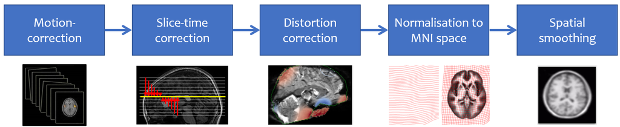

### Preprocessing of structural MRI

Steps:

- Brain extraction (skull-stripping; helps with normalisation),
- brain tissue segmentation (needed for normalisation) and
- spatial normalisation.

#### Lesion masking during normalisation

When processing images from patients with focal brain lesions (e.g., stroke, tumor resection), it is possible to provide a lesion mask to be used during spatial normalisation to standard space. The mask will be used to minimise warping of healthy tissue into damaged areas (or vice-versa). Lesion masks should be binary NIfTI images (damaged areas = 1, everywhere else = 0) in the same space and resolution as the T1 image, and follow the naming convention specified in [BIDS Extension Proposal 3: Common Derivatives](https://docs.google.com/document/d/1Wwc4A6Mow4ZPPszDIWfCUCRNstn7d_zzaWPcfcHmgI4/edit#heading=h.9146wuepclkt) (e.g., `sub-001_T1w_label-lesion_roi.nii.gz`). This file should be placed in the `sub-*/anat` directory of the BIDS dataset to be run through fMRIPrep. Because lesion masks are not currently part of the BIDS specification, it is also necessary to include a `.bidsignore` file in the root of your dataset directory. This will prevent bids-validator from complaining that your dataset is not valid BIDS, which prevents fMRIPrep from running. Your `.bidsignore` file should include the following line: `*lesion_roi.nii.gz`

#### Surface preprocessing

fMRIPrep uses [FreeSurfer](https://surfer.nmr.mgh.harvard.edu/) to reconstruct surfaces from T1w/T2w structural images. If enabled, several steps in the fMRIPrep pipeline are added or replaced. All surface preprocessing may be disabled with the `--fs-no-reconall` flag.

### BOLD preprocessing

#### BOLD reference image estimation

The reference image is used to calculate a brain mask for the BOLD signal, estimate head-motion, and register BOLD to T1w.

If a single-band reference (“sbref”) image associated with the BOLD series is available, then it is used directly. If not, a reference image is estimated from the BOLD series as follows: When T1-saturation effects (“dummy scans” or non-steady state volumes) are detected, they are averaged and used as reference due to their superior tissue contrast. Otherwise, a median of motion corrected subset of volumes is used.

#### Head-motion estimation

Using the previously estimated reference scan, FSL `mcflirt` is used to estimate head-motion. For a more accurate estimation of head-motion, the motion parameters are calculated before any time-domain filtering (i.e., slice-timing correction).

#### Slice time correction

If the `SliceTiming` field is available within the input dataset metadata, this workflow performs slice time correction prior to other signal resampling processes. Slice time correction is performed using AFNI `3dTShift`. All slices are realigned in time to the **middle of each TR**.

Slice time correction can be disabled with the `--ignore slicetiming` command line argument.

#### Susceptibility Distortion Correction

One of the major problems that affects EPI data is the spatial distortion caused by the inhomogeneity of the field inside the scanner. This step applies susceptibility-derived distortion correction, based on fieldmap estimation.

#### Pre-processed BOLD in native space

A new *preproc* BOLD series is generated from the slice-timing corrected (or the original) data in the original space.

#### EPI to T1w registration

The alignment between the reference EPI image of each run and the reconstructed subject using the gray/white matter boundary is calculated by the `bbregister` routine. If FreeSurfer processing is disabled, FSL `flirt` is run with the BBR cost function.

#### Resampling BOLD runs to standard spaces

EPI image is mapped to the standard spaces given by the `--output-spaces` argument (see [Defining standard and nonstandard spaces where data will be resampled](https://fmriprep.org/en/latest/spaces.html#output-spaces)).

#### EPI sampled to FreeSurfer surfaces

If FreeSurfer processing is enabled, the motion-corrected functional series (after single shot resampling to T1w space) is sampled to the surface by averaging across the cortical ribbon.

Surfaces are generated for the “subject native” surface, as well as transformed to the `fsaverage` template space. All surface outputs are in GIFTI format.

#### Confounds estimation

Non-neuronal fluctuations in fMRI data may appear as a result of head motion, scanner noise, or physiological fluctuations (related to cardiac or respiratory effects). For a detailed review of the possible sources of noise in the BOLD signal, see [Greve et al. (2013)](https://doi.org/10.1007/s11336-012-9294-0).

Given a motion-corrected fMRI, a brain mask, movement parameters and a segmentation, potential confounds per volume (time-point) are calculated. Confounding variables calculated in fMRIPrep are stored separately for each subject, session and run in `.tsv` files - one column for each confound variable. Such tabular files may include over 100 columns of potential confound regressors.

It is possible to minimise confounding effects of non-neuronal signals by including them as nuisance regressors in the GLM design matrix. The fMRIPrep pipeline generates a large array of possible confounds. The most well established confounding variables in neuroimaging are the six head-motion parameters (three rotations and three translations) - the common output of the head-motion correction (also known as realignment) of popular fMRI preprocessing software such as SPM or FSL.

**Do not include all columns of `~_desc-confounds_timeseries.tsv` table into your design matrix! Filter the table first, to include only the confounds you want to remove from your fMRI signal.** [See the fMRIPrep confound regressor description](https://fmriprep.org/en/latest/outputs.html#confound-regressors-description). We will demonstrate this in the next notebook.

### fMRIPrep generated Methods section

fMRIPrep creates a nice summary of the steps that you could put into the Methods section of your paper:

> Results included in this manuscript come from preprocessing performed using *fMRIPrep* 21.0.1 (@fmriprep1; @fmriprep2; RRID:SCR_016216), which is based on *Nipype* 1.6.1 (@nipype1; @nipype2; RRID:SCR_002502).

> Preprocessing of B<sub>0</sub> inhomogeneity mappings

> : A total of 1 fieldmaps were found available within the input BIDS structure for this particular subject. A *B<sub>0</sub>* nonuniformity map (or *fieldmap*) was estimated from the phase-drift map(s) measure with two consecutive GRE (gradient-recalled echo) acquisitions. The corresponding phase-map(s) were phase-unwrapped with `prelude` (FSL 6.0.5.1:57b01774).

> Anatomical data preprocessing

> : A total of 1 T1-weighted (T1w) images were found within the input BIDS dataset.The T1-weighted (T1w) image was corrected for intensity non-uniformity (INU) with `N4BiasFieldCorrection` [@n4], distributed with ANTs 2.3.3 [@ants, RRID:SCR_004757], and used as T1w-reference throughout the workflow. The T1w-reference was then skull-stripped with a *Nipype* implementation of the `antsBrainExtraction.sh` workflow (from ANTs), using OASIS30ANTs as target template. Brain tissue segmentation of cerebrospinal fluid (CSF), white-matter (WM) and gray-matter (GM) was performed on the brain-extracted T1w using `fast` [FSL 6.0.5.1:57b01774, RRID:SCR_002823, @fsl_fast]. Brain surfaces were reconstructed using `recon-all` [FreeSurfer 6.0.1, RRID:SCR_001847, @fs_reconall], and the brain mask estimated previously was refined with a custom variation of the method to reconcile ANTs-derived and FreeSurfer-derived segmentations of the cortical gray-matter of Mindboggle [RRID:SCR_002438, @mindboggle]. Volume-based spatial normalization to one standard space (MNI152NLin2009cAsym) was performed through nonlinear registration with `antsRegistration` (ANTs 2.3.3), using brain-extracted versions of both T1w reference and the T1w template. The following template was selected for spatial normalization: *ICBM 152 Nonlinear Asymmetrical template version 2009c* [@mni152nlin2009casym, RRID:SCR_008796; TemplateFlow ID: MNI152NLin2009cAsym].

> Functional data preprocessing

> : For each of the 9 BOLD runs found per subject (across all tasks and sessions), the following preprocessing was performed. First, a reference volume and its skull-stripped version were generated using a custom methodology of *fMRIPrep*. Head-motion parameters with respect to the BOLD reference (transformation matrices, and six corresponding rotation and translation parameters) are estimated before any spatiotemporal filtering using `mcflirt` [FSL 6.0.5.1:57b01774, @mcflirt]. The estimated *fieldmap* was then aligned with rigid-registration to the target EPI (echo-planar imaging) reference run. The field coefficients were mapped on to the reference EPI using the transform. BOLD runs were slice-time corrected to 0.974s (0.5 of slice acquisition range 0s-1.95s) using `3dTshift` from AFNI [@afni, RRID:SCR_005927]. The BOLD reference was then co-registered to the T1w reference using `bbregister` (FreeSurfer) which implements boundary-based registration [@bbr]. Co-registration was configured with six degrees of freedom. Several confounding time-series were calculated based on the *preprocessed BOLD*: framewise displacement (FD), DVARS and three region-wise global signals. FD was computed using two formulations following Power (absolute sum of relative motions, @power_fd_dvars) and Jenkinson (relative root mean square displacement between affines, @mcflirt). FD and DVARS are calculated for each functional run, both using their implementations in *Nipype* [following the definitions by @power_fd_dvars]. The three global signals are extracted within the CSF, the WM, and the whole-brain masks. Additionally, a set of physiological regressors were extracted to allow for component-based noise correction [*CompCor*, @compcor]. Principal components are estimated after high-pass filtering the *preprocessed BOLD* time-series (using a discrete cosine filter with 128s cut-off) for the two *CompCor* variants: temporal (tCompCor) and anatomical (aCompCor). tCompCor components are then calculated from the top 2% variable voxels within the brain mask. For aCompCor, three probabilistic masks (CSF, WM and combined CSF+WM) are generated in anatomical space. The implementation differs from that of Behzadi et al. in that instead of eroding the masks by 2 pixels on BOLD space, the aCompCor masks are subtracted a mask of pixels that likely contain a volume fraction of GM. This mask is obtained by dilating a GM mask extracted from the FreeSurfer's *aseg* segmentation, and it ensures components are not extracted from voxels containing a minimal fraction of GM. Finally, these masks are resampled into BOLD space and binarized by thresholding at 0.99 (as in the original implementation). Components are also calculated separately within the WM and CSF masks. For each CompCor decomposition, the *k* components with the largest singular values are retained, such that the retained components' time series are sufficient to explain 50 percent of variance across the nuisance mask (CSF, WM, combined, or temporal). The remaining components are dropped from consideration. The head-motion estimates calculated in the correction step were also placed within the corresponding confounds file. The confound time series derived from head motion estimates and global signals were expanded with the inclusion of temporal derivatives and quadratic terms for each [@confounds_satterthwaite_2013]. Frames that exceeded a threshold of 0.5 mm FD or 1.5 standardised DVARS were annotated as motion outliers. The BOLD time-series were resampled into standard space, generating a *preprocessed BOLD run in MNI152NLin2009cAsym space*. First, a reference volume and its skull-stripped version were generated using a custom methodology of *fMRIPrep*. All resamplings can be performed with *a single interpolation step* by composing all the pertinent transformations (i.e. head-motion transform matrices, susceptibility distortion correction when available, and co-registrations to anatomical and output spaces). Gridded (volumetric) resamplings were performed using `antsApplyTransforms` (ANTs), configured with Lanczos interpolation to minimize the smoothing effects of other kernels [@lanczos]. Non-gridded (surface) resamplings were performed using `mri_vol2surf` (FreeSurfer).

> Many internal operations of *fMRIPrep* use *Nilearn* 0.8.1 [@nilearn, RRID:SCR_001362], mostly within the functional processing workflow. For more details of the pipeline, see [the section corresponding to workflows in *fMRIPrep*'s documentation](https://fmriprep.readthedocs.io/en/latest/workflows.html).

### Example scipt to run fMRIPrep

For the freesurfer parts of fMRIPrep, you need to get a license file (which is free) from here: [Freesurfer license file](https://surfer.nmr.mgh.harvard.edu/registration.html) (even if you do turn off the recon-all option below). The code below assumes that you have renamed this file to "freesurfer_license.txt" and put in the FaceRecognition directory.

As explained in Section 1 on MRIQC, we call fMRIPrep via an apptainer. This requires binding the working directory to a variable (using the apptainer "-B" command). To preprocess a single participant, you could for example paste the command below into a linux shell (terminal):

```
apptainer run \
        -B /mnt/c/Users/rh01/PythonNeuroimagingCourse/FaceRecognition:/FP \
        /mnt/c/Users/rh01/PythonNeuroimagingCourse/fmriprep_v24.1.1.sif \
        /FP/data \
        /FP/data/derivatives/fmriprep \
        participant \
        --participant-label "15" \
        --fs-license-file /FP/freesurfer_license.txt \
        --work-dir /FP/scratch/fmriprep \
        --output-spaces MNI152NLin2009cAsym:res-2 \
        --fs-no-reconall \
        --nthreads 16 --omp-nthreads 8 \
        --skip-bids-validation \
        --stop-on-first-crash
```

The first line attaches our project directory to the Apptainer app...  
...which is defined by the second line.  
The third line is the BIDS data directory...  
...and the fourth line is the output directory.

The analysis_level is either participant or group (for multiple participants)  
--participant-label: a list of participant identifiers  
--fs-licence-file: the FreeSurfer licence file  
--work-dir: where intermediate output is stored  
--output-spaces: template/atlas used for normalisation  
--fs-no-reconall whether to estimate surfaces too  
--nthreads 16 --omp-nthreads 8 compute options for performance  
--skip-bids-validation: do not check BIDS compliance first  
--stop-on-first-crash: as says on tin

As also noted in Section 1 above, there are many ways to run this apptainer, and here we will call python's `subprocess` library from within this Notebook. Note that this will take many hours to run (kernel will be busy), use 10 times as much diskspace per participant as their raw data, and you only need to preprocess one participant (sub-15) to follow for most of these notebooks (for the group analysis notebook, you can download the preprocessed data for the remaining 15 participants from the OwnCloud link provided in the course notes). Either way, you may want to make a cup of tea...

```python
%%capture output

import subprocess

# If want to run everyone, but it will take many hours!!!
#for sub in range(1,17):
#    subject_ids_str = subject_ids_str + f" {sub:02d}"

# If want to run just subject 15
#subject_ids_str = "15"

# Or if want to skip this cell when running whole notebook to save time
subject_ids_str = ""

command = f"""
apptainer run \
    -B "/mnt/c/Users/rh01/PythonNeuroimagingCourse/FaceRecognition:/FP" \
    /mnt/c/Users/rh01/PythonNeuroimagingCourse/fmriprep_v24.1.1.sif \
    /FP/data \
    /FP/data/derivatives/fmriprep \
    participant \
    --participant-label {subject_ids_str}  \
    --fs-license-file /FP/freesurfer_license.txt \
    --work-dir /FP/scratch/fmriprep \
    --output-spaces MNI152NLin2009cAsym:res-2 \
    --fs-no-reconall \
    --nthreads 16 --omp-nthreads 8 \
    --skip-bids-validation \
    --stop-on-first-crash
"""

if not subject_ids_str == "":
    print(command)
    result = subprocess.run(command, shell=True, check=True, stdout=subprocess.PIPE, stderr=subprocess.PIPE, text=True)
```

Again, if you want to check the screen output from within this Notebook, then run the cell below:

```python
if not subject_ids_str == "":
    #print("out:", output.stdout)
    print("err:", output.stderr)
```

You can also look at the output by:

```python
!tree /mnt/c/Users/rh01/PythonNeuroimagingCourse/FaceRecognition/data/derivatives/fmriprep/sub-15
```

```
/mnt/c/Users/rh01/PythonNeuroimagingCourse/FaceRecognition/data/derivatives/fmriprep/sub-15
├── figures
│   ├── sub-15_ses-mri_acq-mprage_desc-conform_T1w.html
│   ├── sub-15_ses-mri_acq-mprage_dseg.svg
│   ├── sub-15_ses-mri_acq-mprage_space-MNI152NLin2009cAsym_T1w.svg
│   ├── sub-15_ses-mri_desc-about_T1w.html
│   ├── sub-15_ses-mri_desc-summary_T1w.html
│   ├── sub-15_ses-mri_fmapid-auto00000_desc-phasediff_fieldmap.svg
│   ├── sub-15_ses-mri_task-facerecognition_run-01_desc-carpetplot_bold.svg
│   ├── sub-15_ses-mri_task-facerecognition_run-01_desc-compcorvar_bold.svg
│   ├── sub-15_ses-mri_task-facerecognition_run-01_desc-confoundcorr_bold.svg
│   ├── sub-15_ses-mri_task-facerecognition_run-01_desc-coreg_bold.svg
│   ├── sub-15_ses-mri_task-facerecognition_run-01_desc-fmapCoreg_bold.svg
│   ├── sub-15_ses-mri_task-facerecognition_run-01_desc-rois_bold.svg
│   ├── sub-15_ses-mri_task-facerecognition_run-01_desc-sdc_bold.svg
│   ├── sub-15_ses-mri_task-facerecognition_run-01_desc-summary_bold.html
│   ├── sub-15_ses-mri_task-facerecognition_run-01_desc-validation_bold.html
│   ├── sub-15_ses-mri_task-facerecognition_run-02_desc-carpetplot_bold.svg
│   ├── sub-15_ses-mri_task-facerecognition_run-02_desc-compcorvar_bold.svg
│   ├── sub-15_ses-mri_task-facerecognition_run-02_desc-confoundcorr_bold.svg
│   ├── sub-15_ses-mri_task-facerecognition_run-02_desc-coreg_bold.svg
│   ├── sub-15_ses-mri_task-facerecognition_run-02_desc-fmapCoreg_bold.svg
│   ├── sub-15_ses-mri_task-facerecognition_run-02_desc-rois_bold.svg
│   ├── sub-15_ses-mri_task-facerecognition_run-02_desc-sdc_bold.svg
│   ├── sub-15_ses-mri_task-facerecognition_run-02_desc-summary_bold.html
│   ├── sub-15_ses-mri_task-facerecognition_run-02_desc-validation_bold.html
│   ├── sub-15_ses-mri_task-facerecognition_run-03_desc-carpetplot_bold.svg
│   ├── sub-15_ses-mri_task-facerecognition_run-03_desc-compcorvar_bold.svg
│   ├── sub-15_ses-mri_task-facerecognition_run-03_desc-confoundcorr_bold.svg
│   ├── sub-15_ses-mri_task-facerecognition_run-03_desc-coreg_bold.svg
│   ├── sub-15_ses-mri_task-facerecognition_run-03_desc-fmapCoreg_bold.svg
│   ├── sub-15_ses-mri_task-facerecognition_run-03_desc-rois_bold.svg
│   ├── sub-15_ses-mri_task-facerecognition_run-03_desc-sdc_bold.svg
│   ├── sub-15_ses-mri_task-facerecognition_run-03_desc-summary_bold.html
│   ├── sub-15_ses-mri_task-facerecognition_run-03_desc-validation_bold.html
│   ├── sub-15_ses-mri_task-facerecognition_run-04_desc-carpetplot_bold.svg
│   ├── sub-15_ses-mri_task-facerecognition_run-04_desc-compcorvar_bold.svg
│   ├── sub-15_ses-mri_task-facerecognition_run-04_desc-confoundcorr_bold.svg
│   ├── sub-15_ses-mri_task-facerecognition_run-04_desc-coreg_bold.svg
│   ├── sub-15_ses-mri_task-facerecognition_run-04_desc-fmapCoreg_bold.svg
```

[output cut: 248 more lines]

```
        ├── sub-15_ses-mri_task-facerecognition_run-09_desc-hmc_boldref.nii.gz
        ├── sub-15_ses-mri_task-facerecognition_run-09_from-boldref_to-T1w_mode-image_desc-coreg_xfm.json
        ├── sub-15_ses-mri_task-facerecognition_run-09_from-boldref_to-T1w_mode-image_desc-coreg_xfm.txt
        ├── sub-15_ses-mri_task-facerecognition_run-09_from-boldref_to-auto00000_mode-image_xfm.json
        ├── sub-15_ses-mri_task-facerecognition_run-09_from-boldref_to-auto00000_mode-image_xfm.txt
        ├── sub-15_ses-mri_task-facerecognition_run-09_from-orig_to-boldref_mode-image_desc-hmc_xfm.json
        ├── sub-15_ses-mri_task-facerecognition_run-09_from-orig_to-boldref_mode-image_desc-hmc_xfm.txt
        ├── sub-15_ses-mri_task-facerecognition_run-09_space-MNI152NLin2009cAsym_res-2_boldref.json
        ├── sub-15_ses-mri_task-facerecognition_run-09_space-MNI152NLin2009cAsym_res-2_boldref.nii.gz
        ├── sub-15_ses-mri_task-facerecognition_run-09_space-MNI152NLin2009cAsym_res-2_desc-brain_mask.json
        ├── sub-15_ses-mri_task-facerecognition_run-09_space-MNI152NLin2009cAsym_res-2_desc-brain_mask.nii.gz
        ├── sub-15_ses-mri_task-facerecognition_run-09_space-MNI152NLin2009cAsym_res-2_desc-preproc_bold.json
        └── sub-15_ses-mri_task-facerecognition_run-09_space-MNI152NLin2009cAsym_res-2_desc-preproc_bold.nii.gz

9 directories, 292 files
```

And you can manually open files like this one in a browser (e.g, after running "explorer.exe" from an wsl prompt):

```
FaceRecognition/data/derivatives/fmriprep/sub-15.html
```

If you scroll through the images, you can see the results of the various stages of preprocessing.

**Finally, note that fMRIPrep can produce lots of large files in the /scratch directory, which you may want to delete if you have limited diskspace**

## Pre-processing with NiPype

[Nipype](https://nipype.readthedocs.io/en/latest/) is a Python-based framework that facilitates the creation of flexible, reproducible, and scalable neuroimaging workflows. It provides interfaces to a variety of neuroimaging tools and packages, such as FSL, SPM, FreeSurfer, and ANTs, allowing users to integrate different software into a single processing pipeline. Nipype enables seamless automation of data analysis, enhancing reproducibility and reducing the manual effort required in complex neuroimaging workflows.

fMRIPrep is built using Nipype, which means that fMRIPrep takes advantage of Nipype’s ability to integrate multiple software tools into a single workflow.

Here, we will demonstrate a brief example of how to use NiPype to pre-process your fMRI data. In this example, we will only interface with FSL, as it is the tool available on our system.

We will perform realignment and slice-time correction on the functional images and then compare the median temporal signal-to-noise ratio (TSNR) between the raw and pre-processed data. TSNR is a commonly used metric in fMRI analysis that quantifies the quality of the time series data at each voxel.

```python
# Create the TSNR function

import nibabel as nib
import numpy as np

# Function for tsnr calculation
def calculate_tsnr(image):
    # Load the MRI image data
    # if image is a filename, load it
    if isinstance(image, str):
        image = nib.load(image)
    data = image.get_fdata()

    # Compute the mean signal intensity
    mean_signal = np.mean(data, axis=3)

    # Compute the standard deviation of the signal
    std_signal = np.std(data, axis=3)

    # Compute the SNR map
    # Avoid division by zero
    snr_map = np.divide(mean_signal, std_signal, where=(std_signal!=0))

    # replace zeros with NaN
    snr_map[std_signal == 0] = np.nan

    # Get median SNR
    median_snr = np.median(snr_map[~np.isnan(snr_map)])

    return median_snr
```

```python
# Set up NiPype environment

import nipype.pipeline.engine as pe
import nipype.interfaces.fsl as fsl

# Load BIDS layout
from bids.layout import BIDSLayout
bids_dir = '/mnt/c/Users/rh01/PythonNeuroimagingCourse/FaceRecognition/data'
bids_layout = BIDSLayout(bids_dir, derivatives=False)
```

```python
# Get subject's T1w image and all Bold images
t1w = bids_layout.get(subject='15', datatype='anat', suffix='T1w', extension='nii.gz', return_type='filename')
t1w = t1w[0]
bold = bids_layout.get(subject='15', datatype='func', suffix='bold', extension='nii.gz', return_type='filename')

# run 1 bold
bold_run1 = bold[0]
print(bold_run1)

print(t1w)
```

```
/mnt/c/Users/rh01/PythonNeuroimagingCourse/FaceRecognition/data/sub-15/ses-mri/func/sub-15_ses-mri_task-facerecognition_run-01_bold.nii.gz
/mnt/c/Users/rh01/PythonNeuroimagingCourse/FaceRecognition/data/sub-15/ses-mri/anat/sub-15_ses-mri_acq-mprage_T1w.nii.gz
```

```python
# Get the number of slices from the BIDS layout
metadata = bids_layout.get_metadata(bold_run1)
num_slices = metadata['SliceTiming']
num_slices = len(num_slices)
print(num_slices)

# Get the TR from the BIDS layout
TR = metadata['RepetitionTime']
print(TR)

# Get slice order from the BIDS layout
slice_order = metadata['SliceTiming']
print(slice_order)

# Define the filename for the slice timing file
slice_order_filename = '/mnt/c/Users/rh01/PythonNeuroimagingCourse/FaceRecognition/scratch/slice_timing.txt'

# Open the file and write each timing value to a new line
with open(slice_order_filename, 'w') as file:
    for timing in slice_order:
        file.write(f"{timing}\n")  # Write each timing followed by a newline character

print(f"Slice timings have been saved to {slice_order_filename}")
```

```
33
2
[0, 1.035, 0.06, 1.095, 0.1225, 1.155, 0.1825, 1.2175, 0.2425, 1.2775, 0.305, 1.3375, 0.365, 1.4, 0.425, 1.46, 0.4875, 1.52, 0.5475, 1.5825, 0.6075, 1.6425, 0.67, 1.7025, 0.73, 1.765, 0.79, 1.825, 0.8525, 1.885, 0.9125, 1.9475, 0.9725]
Slice timings have been saved to /mnt/c/Users/rh01/PythonNeuroimagingCourse/FaceRecognition/scratch/slice_timing.txt
```

Set up a simple NiPype pipeline to perform two common fMRI preprocessing steps using FSL: **motion correction (realignment)** and **slice timing correction**.

```python
realign = pe.Node(interface = fsl.MCFLIRT(), name = 'realign')
realign.inputs.in_file = bold_run1
realign.inputs.cost = 'mutualinfo'
realign.inputs.save_plots = True
realign.inputs.output_type = 'NIFTI_GZ'
```

**Motion Correction (Realignment):**

- `pe.Node`: This creates a node in the NiPype pipeline. A Node represents a single step in the processing pipeline.
- `fsl.MCFLIRT()`: This calls the FSL tool MCFLIRT (Motion Correction using FMRIB’s Linear Image Registration Tool) to correct for head motion in fMRI data.
- `realign.inputs.in_file`: Specifies the input file (e.g., the first BOLD run) that will be realigned for motion correction.
- `realign.inputs.cost = 'mutualinfo'`: Uses the mutual information cost function for the registration, which is often good for aligning images from different modalities or significantly different acquisitions.
- `realign.inputs.save_plots = True`: Saves motion correction plots for visual inspection of head motion during the scan.
- `realign.inputs.output_type = 'NIFTI_GZ'`: Specifies the output format for the corrected image (compressed NIfTI format).

```python
slicetime = pe.Node(interface = fsl.SliceTimer(), name = 'slicetime')
slicetime.inputs.time_repetition = TR
slicetime.inputs.custom_timings = slice_order_filename
slicetime.inputs.interleaved = False
slicetime.inputs.output_type = 'NIFTI_GZ'
```

**Slice Timing Correction:**

Next, we chain the motion correction and slice timing correction steps, and generate plots of the motion parameters.

```python
# name of the workflow
preprocessing = pe.Workflow(name="preprocessing")

# The output of the realignment (motion-corrected functional image) is passed to the slice timing correction step.
preprocessing.connect(realign, "out_file", slicetime, "in_file")

# generate motion parameter plots
plot_motion = pe.MapNode(
    interface=fsl.PlotMotionParams(in_source='fsl'),
    name='plot_motion',
    iterfield=['in_file'])
plot_motion.iterables = ('plot_type', ['rotations', 'translations'])
preprocessing.connect(realign, 'par_file', plot_motion, 'in_file')
```

```
241229-16:59:17,474 nipype.workflow INFO:
	 Generated workflow graph: scratch/preprocessing/graph.png (graph2use=colored, simple_form=True).
```

```
2024-12-29 16:59:17,474 [    INFO] Generated workflow graph: scratch/preprocessing/graph.png (graph2use=colored, simple_form=True).
```

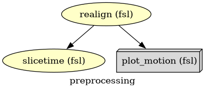

```python
# working directory for the workflow, where intermediate and final output files will be saved
preprocessing.base_dir = 'scratch'

# Create the workflow graph
preprocessing.write_graph(graph2use='colored', format='png', simple_form=True)

# Visualize the graph
from IPython.display import Image
import os
Image(filename=os.path.join(preprocessing.base_dir, 'preprocessing', 'graph.png'))
```

```
241229-16:59:17,781 nipype.workflow INFO:
	 Generated workflow graph: /mnt/c/Users/rh01/PythonNeuroimagingCourse/FaceRecognition/scratch/preprocessing/graph.png (graph2use=flat, simple_form=True).
```

```
2024-12-29 16:59:17,781 [    INFO] Generated workflow graph: /mnt/c/Users/rh01/PythonNeuroimagingCourse/FaceRecognition/scratch/preprocessing/graph.png (graph2use=flat, simple_form=True).
```

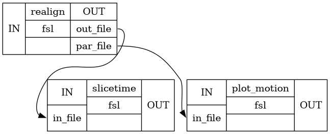

```python
# Visualize the detailed graph
preprocessing.write_graph(graph2use='flat', format='png', simple_form=True)
Image(filename=os.path.join(preprocessing.base_dir, 'preprocessing', 'graph_detailed.png'))
```

```python
# run the workflow (Note that you will need FSL installed...)
preprocessing.run()
```

```
241229-16:59:17,834 nipype.workflow INFO:
	 Workflow preprocessing settings: ['check', 'execution', 'logging', 'monitoring']
```

```
2024-12-29 16:59:17,834 [    INFO] Workflow preprocessing settings: ['check', 'execution', 'logging', 'monitoring']
```

```
241229-16:59:17,886 nipype.workflow INFO:
	 Running serially.
```

```
2024-12-29 16:59:17,886 [    INFO] Running serially.
```

```
241229-16:59:17,888 nipype.workflow INFO:
	 [Node] Setting-up "preprocessing.realign" in "/mnt/c/Users/rh01/PythonNeuroimagingCourse/FaceRecognition/scratch/preprocessing/realign".
```

```
2024-12-29 16:59:17,888 [    INFO] [Node] Setting-up "preprocessing.realign" in "/mnt/c/Users/rh01/PythonNeuroimagingCourse/FaceRecognition/scratch/preprocessing/realign".
```

```
241229-16:59:17,932 nipype.workflow INFO:
	 [Node] Executing "realign" <nipype.interfaces.fsl.preprocess.MCFLIRT>
```

```
2024-12-29 16:59:17,932 [    INFO] [Node] Executing "realign" <nipype.interfaces.fsl.preprocess.MCFLIRT>
```

```
241229-16:59:56,319 nipype.workflow INFO:
	 [Node] Finished "realign", elapsed time 38.382984s.
```

```
2024-12-29 16:59:56,319 [    INFO] [Node] Finished "realign", elapsed time 38.382984s.
```

```
241229-16:59:56,372 nipype.workflow INFO:
	 [Node] Setting-up "preprocessing.slicetime" in "/mnt/c/Users/rh01/PythonNeuroimagingCourse/FaceRecognition/scratch/preprocessing/slicetime".
```

```
2024-12-29 16:59:56,372 [    INFO] [Node] Setting-up "preprocessing.slicetime" in "/mnt/c/Users/rh01/PythonNeuroimagingCourse/FaceRecognition/scratch/preprocessing/slicetime".
```

```
241229-16:59:56,448 nipype.workflow INFO:
	 [Node] Executing "slicetime" <nipype.interfaces.fsl.preprocess.SliceTimer>
```

```
2024-12-29 16:59:56,448 [    INFO] [Node] Executing "slicetime" <nipype.interfaces.fsl.preprocess.SliceTimer>
```

```
241229-17:00:06,970 nipype.workflow INFO:
	 [Node] Finished "slicetime", elapsed time 10.518457s.
```

```
2024-12-29 17:00:06,970 [    INFO] [Node] Finished "slicetime", elapsed time 10.518457s.
```

```
241229-17:00:07,96 nipype.workflow INFO:
	 [Node] Setting-up "_plot_motion0" in "/mnt/c/Users/rh01/PythonNeuroimagingCourse/FaceRecognition/scratch/preprocessing/_plot_type_rotations/plot_motion/mapflow/_plot_motion0".
```

```
2024-12-29 17:00:07,096 [    INFO] [Node] Setting-up "_plot_motion0" in "/mnt/c/Users/rh01/PythonNeuroimagingCourse/FaceRecognition/scratch/preprocessing/_plot_type_rotations/plot_motion/mapflow/_plot_motion0".
```

```
241229-17:00:07,150 nipype.workflow INFO:
	 [Node] Executing "_plot_motion0" <nipype.interfaces.fsl.utils.PlotMotionParams>
```

```
2024-12-29 17:00:07,150 [    INFO] [Node] Executing "_plot_motion0" <nipype.interfaces.fsl.utils.PlotMotionParams>
```

```
241229-17:00:07,315 nipype.workflow INFO:
	 [Node] Finished "_plot_motion0", elapsed time 0.16094s.
```

```
2024-12-29 17:00:07,315 [    INFO] [Node] Finished "_plot_motion0", elapsed time 0.16094s.
```

```
241229-17:00:07,521 nipype.workflow INFO:
	 [Node] Setting-up "_plot_motion0" in "/mnt/c/Users/rh01/PythonNeuroimagingCourse/FaceRecognition/scratch/preprocessing/_plot_type_translations/plot_motion/mapflow/_plot_motion0".
```

```
2024-12-29 17:00:07,521 [    INFO] [Node] Setting-up "_plot_motion0" in "/mnt/c/Users/rh01/PythonNeuroimagingCourse/FaceRecognition/scratch/preprocessing/_plot_type_translations/plot_motion/mapflow/_plot_motion0".
```

```
241229-17:00:07,586 nipype.workflow INFO:
	 [Node] Executing "_plot_motion0" <nipype.interfaces.fsl.utils.PlotMotionParams>
```

```
2024-12-29 17:00:07,586 [    INFO] [Node] Executing "_plot_motion0" <nipype.interfaces.fsl.utils.PlotMotionParams>
```

```
241229-17:00:07,824 nipype.workflow INFO:
	 [Node] Finished "_plot_motion0", elapsed time 0.2312s.
```

```
2024-12-29 17:00:07,824 [    INFO] [Node] Finished "_plot_motion0", elapsed time 0.2312s.
```

```
<networkx.classes.digraph.DiGraph at 0x7f21aa7aa7d0>
```

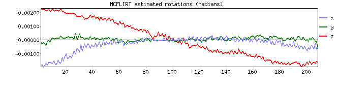

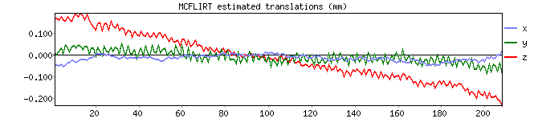

```python
# display the motion parameters
from IPython.display import display

# Display the image
display(Image(filename='scratch/preprocessing/realign/sub-15_ses-mri_task-facerecognition_run-01_bold_mcf.nii.gz_rot.png', width=800))
display(Image(filename='scratch/preprocessing/realign/sub-15_ses-mri_task-facerecognition_run-01_bold_mcf.nii.gz_trans.png', width=800))
```

Calculate the TSNR for three versions of a BOLD image (raw, realigned, and slice-time corrected) using the previously defined `calculate_tsnr()` function to assess the impact of preprocessing steps on the data quality and confirm whether the preprocessing improves the signal-to-noise ratio.

```python
realigned_image = 'scratch/preprocessing/realign/sub-15_ses-mri_task-facerecognition_run-01_bold_mcf.nii.gz'
slicetime_corrected_image = 'scratch/preprocessing/slicetime/sub-15_ses-mri_task-facerecognition_run-01_bold_mcf_st.nii.gz'

tsnr_raw = calculate_tsnr(bold_run1)
tsnr_realign = calculate_tsnr(realigned_image)
tsnr_slicetime = calculate_tsnr(slicetime_corrected_image)

print(f"TSNR for raw image: {tsnr_raw:.3f}")
print(f"TSNR for realigned image: {tsnr_realign:.3f}")
print(f"TSNR for slice-time corrected image: {tsnr_slicetime:.3f}")
```

```
TSNR for raw image: 5.546
TSNR for realigned image: 5.856
TSNR for slice-time corrected image: 6.228
```